# Untitled

2022-08-01

# Distribuições multivariadas

1. Considere um vetor bivariado de variáveis aleatórias normalmente distribuído, com $E(Y_1) = 0$, $E(Y_2) = 4$, $V(Y_1) = 1$, $V(Y_2) = 9$ e $Cov(Y_1, Y_2) = 2$.
1. Escreva a função de densidade de probabilidade.

$f(\mathbf{y}) = \left( \dfrac{1}{2\pi} \right)^{\frac{p}{2}} \det(\Sigma)^{-\frac{1}{2}} \exp \Bigl\{ -\dfrac{1}{2}(\mathbf{y} - \mathbf{\mu})^T \Sigma^{-1} (\mathbf{y} - \mathbf{\mu}) \Bigl\}$

$\det(\mathbf{\Sigma}) = \det \left( \begin{bmatrix} 1 & 2 \\ 2 & 9 \\ \end{bmatrix} \right) = 5$

$(\mathbf{y} - \mathbf{\mu}) = \begin{bmatrix} y_1 \\ y_2 \\ \end{bmatrix} - \begin{bmatrix} 0 \\ 4 \\ \end{bmatrix} = \begin{bmatrix} y_1 \\ y_2 - 4 \\ \end{bmatrix}$

$\Sigma^{-1} = \begin{bmatrix} 1 & 2 \\ 2 & 9 \\ \end{bmatrix}^{-1} = \begin{bmatrix} 1.8 & -0.4 \\ -0.4 & 0.2 \\ \end{bmatrix}$

$f(y_1, y_2) = \left( \dfrac{1}{2\pi} \right) 5^{-\frac{1}{2}} \exp \Bigl\{ -\dfrac{1}{2} \begin{bmatrix} y_1 & (y_2 - 4) \\ \end{bmatrix} \cdot \begin{bmatrix} 1.8 & -0.4 \\ -0.4 & 0.2 \\ \end{bmatrix} \cdot \begin{bmatrix} y_1 \\ (y_2 - 4) \\ \end{bmatrix} \Bigl\}$

$\begin{bmatrix} y_1 & (y_2 - 4) \\ \end{bmatrix} \cdot \begin{bmatrix} 1.8 & -0.4 \\ -0.4 & 0.2 \\ \end{bmatrix} = \begin{bmatrix} 1.8y_1 - 0.4y_2 + 1.6 & -0.4y_1 + 0.2y_2 - 0.8 \\ \end{bmatrix}$

$f(y_1, y_2) = \left( \dfrac{1}{2\pi} \right) 5^{-\frac{1}{2}} \exp \Bigl\{ -\dfrac{1}{2} \begin{bmatrix} 1.8y_1 - 0.4y_2 + 1.6 & -0.4y_1 + 0.2y_2 - 0.8 \\ \end{bmatrix} \cdot \begin{bmatrix} y_1 \\ (y_2 - 4) \\ \end{bmatrix} \Bigl\}$

$\begin{bmatrix} 1.8y_1 - 0.4y_2 + 1.6 & -0.4y_1 + 0.2y_2 - 0.8 \\ \end{bmatrix} \cdot \begin{bmatrix} y_1 \\ (y_2 - 4) \\ \end{bmatrix} = 1.8y_1^2 + 0.2y_2^2 - 0.8y_1y_2 + 3.2y_1 - 1.6y_2 + 3.2$

$f(y_1, y_2) = \left( \dfrac{1}{2\pi} \right) 5^{-\frac{1}{2}} \exp \Bigl\{ -\dfrac{1}{2} (1.8y_1^2 + 0.2y_2^2 - 0.8y_1y_2 + 3.2y_1 - 1.6y_2 + 3.2) \Bigl\}$

$f(y_1, y_2) = \left( \dfrac{1}{2\pi} \right) 5^{-\frac{1}{2}} \exp \Bigl\{ -0.9y_1^2 -0.1y_2^2 +0.4y_1y_2 - 1.6y_1 + 0.8y_2 -1.6 \Bigl\}$

$f(y_1, y_2) = \dfrac{1}{2\pi \sqrt{5}} \exp \Bigl\{ -0.9y_1^2 -0.1y_2^2 +0.4y_1y_2 - 1.6y_1 + 0.8y_2 -1.6 \Bigl\}$

2. Implemente tal densidade computacionalmente

```r
f <- function(y1, y2) {
  out <- 1/(2*pi*sqrt(5)) * exp(-0.9*y1^2 - 0.1*y2^2 + 0.4*y1*y2 - 1.6*y1 + 0.8*y2 - 1.6)
  return(out)
}

f(0,1)
```

```
## [1] 0.02893811
```

```r
library(mvtnorm)

Sigma = matrix(c(1,2,2,9), nrow = 2)
mu = c(0,4)

dmvnorm(x=c(0,1), mean=mu, sigma=Sigma)
```

```
## [1] 0.02893811
```

3. Desenhe o gráfico da função de densidade bivariada.

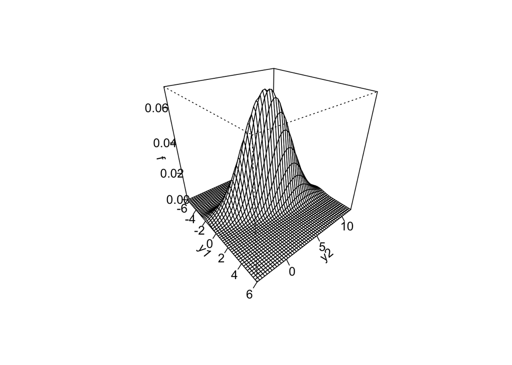

```r
y1 <- seq(-6, 6, length = 50)
y2 <- seq(-4, 12, length = 50)

f <- matrix(0, nrow=length(y1), ncol=length(y2))

for (i in 1:length(y1))
  for (j in 1: length(y2))
    f[i,j] <- dmvnorm(c(y1[i],y2[j]), mean=mu, sigma=Sigma)

 persp(y1, y2, f, theta = 50, phi = 30, ticktype = "detailed")
```

2. Medidas de colesterol foram tomadas em um grande conjunto de pacientes que tiveram ataque do coração. Para cada paciente, medidas foram tomadas no dia 0, 2 e 4 após o ataque. Denote as respectivas VAs por $X_0$, $X_2$ e $X_4$. O vetor de médias foi $(\mu_0 = 259.5, \mu_2 = 230,8, \mu_4 = 221.5)^T$. A matriz de covariância é a seguinte:

$$\begin{bmatrix}
2276 & 1508 & 813 \\
1508 & 2206 & 1349 \\
813 & 1349 & 1865 \\
\end{bmatrix}$$

.

1. Suponha que estamos interessados na distribuição de $X_0 - X_2$. Encontre nesta distribuição sua média e variância.

Referência: https://www.inf.ufsc.br/~andre.zibetti/probabilidade/soma-de-variaveis-aleatorias.html

$\mathbf{\Sigma} = \begin{bmatrix} 2276 & 1508 \\ 1508 & 2206 \\ \end{bmatrix}$

$\mathbf{\mu} = \begin{bmatrix} 259.5 \\ 230.8 \\ \end{bmatrix}$

$Z = X_0 - X_2$

$\mu_Z = \mu_0 - \mu_2 = 259.5 - 230.8 = 28.7$

$\sigma^2_Z = \sigma^2_0 + \sigma^2_2 - 2Cov(X_0, X_2) = 2276 + 2206 - 2(1508) = 1466$

Método matricial:

$\mathbf{a} = \begin{bmatrix} 1 \\ -1 \\ \end{bmatrix}$

$\mathbf{\mu_Z} = \mathbf{a}^T \mathbf{\mu} = \begin{bmatrix} 1 & -1\\ \end{bmatrix} \cdot \begin{bmatrix} 259.5 \\ 230.8 \\ \end{bmatrix} = 259.5 + (-1)230.8 = 28.7$

$\mathbf{\sigma^2_Z} = \mathbf{a}^T \mathbf{\Sigma} \mathbf{a} = \begin{bmatrix} 1 & -1\\ \end{bmatrix} \cdot \begin{bmatrix} 2276 & 1508 \\ 1508 & 2206 \\ \end{bmatrix} \cdot \begin{bmatrix} 1 \\ -1 \\ \end{bmatrix} = \begin{bmatrix} 768 & -698 \\ \end{bmatrix} \cdot \begin{bmatrix} 1 \\ -1 \\ \end{bmatrix} = 1466$

2. Suponha que um paciente apresentou $x_0 = 260$. Calcule o valor esperado para $X_2$ e $X_4$ e suas respectivas variâncias. Forneça um intervalo de confiança com 95% de confiança.

$\mu_{2 \mid 0} = \mu_2 + \dfrac{cov_{20}}{\sigma^2_0}(x_0 - \mu_0) = 230.8 + \dfrac{1508}{2276}(260 - 259.5) = 231.1313$

$\mu_{4 \mid 0} = \mu_4 + \dfrac{cov_{40}}{\sigma^2_0}(x_0 - \mu_0) = 221.5 + \dfrac{813}{2276}(260 - 259.5) = 221.6786$

Como calcular o intervalo de confiança sem saber qual é o $n$ da amostra?

3. Calcule a probabilidade de $X_4$ ser maior que $270$ para um paciente que chegou com colesterou de 250.

$P(X_4 >= 270 \mid x_0 = 250) = ?$

$\mu_{4 \mid 0} = \mu_4 + \dfrac{cov_{40}}{\sigma^2_0}(x_0 - \mu_0) = 221.5 + \dfrac{813}{2276}(250 - 259.5) = 218.1065$

$\sigma^2_{4 \mid 0} = \sigma^2_4 - \dfrac{cov_{04} \cdot cov_{40}}{\sigma^2_0} = 1865 - \dfrac{813^2}{2276} = 1574.592$

$Z \sim N(218.1065, 1574.592)$

$P(Z \leq 270) = \Phi \left( \dfrac{270 - 218.1065}{\sqrt{1574.592}} \right) = \Phi(1.307763) = 0.9045231$

$P(Z > 270) = 1 - P(Z \leq 270) = 1 - 0.9045231 = 0.0954769$

4. Obtenha a matriz de correlação.

$\rho_{12} = \rho_{21} = \dfrac{cov_{12}}{\sqrt{\sigma_1^2 \sigma_2^2}} = \dfrac{1508}{\sqrt{2276 \cdot 2206}} = 0.672996$

$\rho_{13} = \rho_{31} = \dfrac{cov_{13}}{\sqrt{\sigma_1^2 \sigma_3^2}} = \dfrac{813}{\sqrt{2276 \cdot 1865}} = 0.3946072$

$\rho_{23} = \rho_{32} = \dfrac{cov_{23}}{\sqrt{\sigma_2^2 \sigma_3^2}} = \dfrac{1349}{\sqrt{2206 \cdot 1865}} = 0.6650737$

$\mathbf{\rho} = \begin{bmatrix} 1 & 0.672996 & 0.3946072 \\ 0.672996 & 1 & 0.6650737 \\ 0.3946072 & 0.6650737 & 1 \\ \end{bmatrix}$

3. Um dado é lançado 12 vezes. Seja $X_i$ o número de jogadas em que cada $i$ caiu para cima, para $i = 1, \ldots, 6.$
1. Calcule a esperança de $X_i$.

$E(X_i) = n \cdot p_i$

$E(X_i) = 12 \cdot 1/6 = 2$

2. Calcule a variância de $X_i$.

$V(X_i) = n \cdot p_i(1 - p_i)$

3. Calcule a probabilidade de cada uma das faces cair para cima exatamente duas vezes.

$\mathbf{x} = (2, 2, 2, 2, 2, 2)^T$

$\mathbf{p} = (\frac{1}{6}, \frac{1}{6}, \frac{1}{6}, \frac{1}{6}, \frac{1}{6}, \frac{1}{6})^T$

$n = 12$

$k = 6$

$P(X_1 = x_1, X_2 = x_2, X_3 = x_3, X_4 = x_4, X_5 = x_5, X_6 = x_6) = \dfrac{n!}{\prod_{i=1}^k x_i!} \prod\limits_{i=1}^k p_i^{x_i}$

$P(X_1 = 2, X_2 = 2, X_3 = 2, X_4 = 2, X_5 = 2, X_6 = 2) = \dfrac{12!}{2!^6} \cdot \left [ \left(\frac{1}{6}\right)^2 \right]^6$

$P(X_1 = 2, X_2 = 2, X_3 = 2, X_4 = 2, X_5 = 2, X_6 = 2) = \dfrac{12!}{2!^6} \cdot \left( \frac{1}{36} \right)^6$

$P(X_1 = 2, X_2 = 2, X_3 = 2, X_4 = 2, X_5 = 2, X_6 = 2) = 0.003438286$

4. Implemente um código computacional ilustrando essa situação. Tente de forma aproximada calcular a probabilidade do item c).

```r
F_mult <- function(x, p) {
  n <- sum(x)
  prod_x <- c()
  prod_p <- c()

  for (i in 1:length(x)) {
    prod_x <- append(prod_x, factorial(x[i]))
    prod_p <- append(prod_p, p[i]^x[i])
  }

  prod_x <- prod(prod_x)
  prod_p <- prod(prod_p)
  prob <- (factorial(n) / prod_x) * prod_p

  return(prob)

}

x <- c(2,2,2,2,2,2)
p <- c(1/6, 1/6, 1/6, 1/6, 1/6, 1/6)
F_mult(x, p)
```

```
## [1] 0.003438286
```

```r
library(stats)
dmultinom(x, 12, p)
```

```
## [1] 0.003438286
```